[output not shown]

# 1 Load Data and Libraries

```r
library(dplyr)
library(ggplot2)
library(gridExtra)
library(lubridate)
```

The .csv file cleaned from separate file. All dates converted from string to ‘date’ datatype.

```r
# df1_fctr <- read.csv("dataset_Fall 2021.csv", header = TRUE, stringsAsFactors = TRUE)
# # df1_str <- read.csv("dataset_Fall 2021.csv", header = TRUE, stringsAsFactors = FALSE)
# df2 <- df1_fctr
#
# date_cols = c(2,13,14,30,32,34,36,38,40,41) #all the cols that should be dates.
# df2[,date_cols] <- lapply(df2[, date_cols], as.Date)
# df3 <- df2 %>%
#   mutate(msa = as.factor(msa))

load('df3.Rdata')
```

# 2 Exploratory data analysis

Below shows some basic information about the original dataframe.

```r
# str(df3)
summary(df3)
```

```
##     LOAN_ID             LAST_DTE            LAST_STAT      ORIG_CHN
##  Min.   :9.747e+07   Min.   :2000-02-01   P      :195446   B: 13075
##  1st Qu.:2.472e+11   1st Qu.:2010-12-01   C      : 70518   C:131861
##  Median :4.735e+11   Median :2017-03-01   D      :  1758   R:125033
##  Mean   :4.820e+11   Mean   :2015-04-13   F      :  1439
##  3rd Qu.:7.224e+11   3rd Qu.:2021-03-01   T      :   273
##  Max.   :1.000e+12   Max.   :2021-03-01   R      :   214
##                                           (Other):   321
##                                 SELLER                          SERVICER
##  Other                             :139049   Other                  :125946
##  Wells Fargo Bank, N.A.            : 30460   Wells Fargo Bank, N.A. : 37033
##  Jpmorgan Chase Bank, Na           : 15331   Jpmorgan Chase Bank, Na: 11317
##  Bank Of America, N.A.             : 13036   Bank Of America, N.A.  : 11297
##  U.S. Bank N.A.                    :  7972   U.S. Bank N.A.         :  8211
##  Franklin American Mortgage Company:  7486   Citimortgage, Inc.     :  7155
##  (Other)                           : 56635   (Other)                : 69010
##     orig_rt          LAST_RT          orig_amt         ORIG_VAL
##  Min.   : 2.250   Min.   : 2.000   Min.   :  9000   Min.   :  10000
##  1st Qu.: 3.875   1st Qu.: 3.875   1st Qu.: 92000   1st Qu.: 126250
##  Median : 4.625   Median : 4.625   Median :131000   Median : 175000
##  Mean   : 4.859   Mean   : 4.854   Mean   :150326   Mean   : 205669
##  3rd Qu.: 5.875   3rd Qu.: 5.875   3rd Qu.:190000   3rd Qu.: 253947
##  Max.   :11.500   Max.   :11.500   Max.   :510000   Max.   :6950000
##                   NA's   :2
##     LAST_UPB         orig_trm        ORIG_DTE             FRST_DTE
##  Min.   :     0   Min.   : 60.0   Min.   :1999-02-01   Min.   :1999-04-01
##  1st Qu.: 70098   1st Qu.:180.0   1st Qu.:2005-06-01   1st Qu.:2005-08-01
##  Median :111346   Median :360.0   Median :2011-11-01   Median :2012-01-01
##  Mean   :126716   Mean   :300.8   Mean   :2011-01-02   Mean   :2011-03-04
##  3rd Qu.:167133   3rd Qu.:360.0   3rd Qu.:2016-05-01   3rd Qu.:2016-07-01
##  Max.   :509143   Max.   :360.0   Max.   :2020-06-01   Max.   :2020-08-01
##  NA's   :6869
##       oltv           ocltv            num_bo           dti           CSCORE_B
##  Min.   : 4.00   Min.   :  4.00   Min.   :1.000   Min.   : 1.00   Min.   :447
##  1st Qu.:68.00   1st Qu.: 69.00   1st Qu.:1.000   1st Qu.:24.00   1st Qu.:724
##  Median :80.00   Median : 80.00   Median :2.000   Median :32.00   Median :765
##  Mean   :75.21   Mean   : 75.98   Mean   :1.648   Mean   :32.21   Mean   :753
##  3rd Qu.:85.00   3rd Qu.: 88.00   3rd Qu.:2.000   3rd Qu.:40.00   3rd Qu.:791
##  Max.   :97.00   Max.   :146.00   Max.   :8.000   Max.   :64.00   Max.   :850
##                                   NA's   :24      NA's   :3410    NA's   :736
```

[output cut: 33 more lines]

```
##  Min.   :2000-12-01   Min.   :     0   Min.   :2000-06-01
##  1st Qu.:2009-07-01   1st Qu.: 63858   1st Qu.:2007-10-01
##  Median :2012-12-01   Median : 96825   Median :2010-01-01
##  Mean   :2013-11-13   Mean   :116535   Mean   :2010-02-23
##  3rd Qu.:2020-09-01   3rd Qu.:147409   3rd Qu.:2012-05-01
##  Max.   :2021-03-01   Max.   :510000   Max.   :2020-01-01
##  NA's   :265258       NA's   :265258   NA's   :268051
##     FCC_DTE              NET_LOSS      relo_flg
##  Min.   :2001-03-01   Min.   :-94155   N:268143
##  1st Qu.:2008-10-01   1st Qu.:  1612   Y:  1826
##  Median :2011-03-01   Median : 16298
##  Mean   :2011-03-30   Mean   : 22671
##  3rd Qu.:2013-09-01   3rd Qu.: 35163
##  Max.   :2021-03-01   Max.   :284075
##  NA's   :268050       NA's   :268064
```

## 2.1 Simple Graphs

### 2.1.1 Entries with different start & end interest rates more likely to fail

```r
df3[is.na(df3$LAST_RT),]
```

```
##            LOAN_ID   LAST_DTE LAST_STAT ORIG_CHN                  SELLER
## 49259 235941281018 2004-01-01         R        C Jpmorgan Chase Bank, Na
## 86135 969195685029 2008-01-01         P        B            Amtrust Bank
##       SERVICER orig_rt LAST_RT orig_amt  ORIG_VAL LAST_UPB orig_trm   ORIG_DTE
## 49259            5.500      NA    50000  51546.39       NA      360 2003-11-01
## 86135            6.625      NA   149000 186250.00       NA      360 2007-10-01
##         FRST_DTE oltv ocltv num_bo dti CSCORE_B CSCORE_C FTHB_FLG purpose
## 49259 2004-01-01   97    97      2  19      742       NA        Y       P
## 86135 2007-12-01   80    80      2  32      661      650        N       P
##       PROP_TYP NUM_UNIT occ_stat state   msa zip_3 mi_pct F30_DTE F30_UPB
## 49259       CO        1        P    NE 30700   685     35    <NA>      NA
## 86135       SF        1        P    NE 36540   680     NA    <NA>      NA
##       F60_DTE F60_UPB F90_DTE F90_UPB F120_DTE F120_UPB F180_DTE F180_UPB
## 49259    <NA>      NA    <NA>      NA     <NA>       NA     <NA>       NA
## 86135    <NA>      NA    <NA>      NA     <NA>       NA     <NA>       NA
##       LPI_DTE FCC_DTE NET_LOSS relo_flg
## 49259    <NA>    <NA>       NA        N
## 86135    <NA>    <NA>       NA        N
```

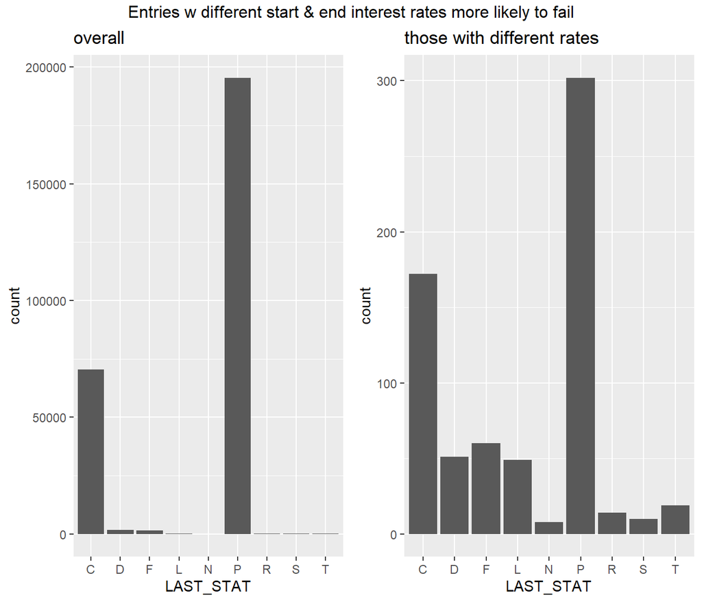

```r
df3[is.na(df3$LAST_RT),"LAST_RT"] <- df3[is.na(df3$LAST_RT),"orig_rt"] # fill in 2 NAs in `LAST_RT`.

df3_diff_rt <- df3 %>%
  filter(LAST_RT != orig_rt)

p_RtDiff1 <- ggplot(df3, aes(x=LAST_STAT)) + geom_bar() + ggtitle('overall')
p_RtDiff2 <- ggplot(df3_diff_rt, aes(x=LAST_STAT)) + geom_bar() + ggtitle('those with different rates')

grid.arrange(p_RtDiff1, p_RtDiff2, nrow = 1, top="Entries w different start & end interest rates more likely to fail")
```

### 2.1.2 Transform right-skewed data through log or cube root transformation

First, for `orig_amt`, or Original UPB.

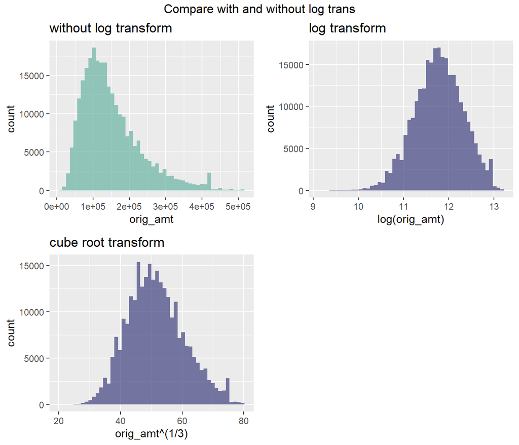

```r
mybins <- 50

p_trans_orig_amt1 <- ggplot(df3, aes(orig_amt)) +
  geom_histogram(bins = mybins, fill = '#69b3a2' ,alpha= 0.7) +
  ggtitle('without log transform')
p_trans_orig_amt2 <- ggplot(df3, aes(log(orig_amt))) +
  geom_histogram(bins = mybins, fill = '#404080' ,alpha= 0.7) +
  ggtitle('log transform')
p_trans_orig_amt3 <- ggplot(df3, aes(orig_amt^(1/3))) +
  geom_histogram(bins = mybins, fill = '#404080' ,alpha= 0.7) +
  ggtitle('cube root transform')

grid.arrange(p_trans_orig_amt1, p_trans_orig_amt2, p_trans_orig_amt3,
             nrow = 2, top="Compare with and without log trans")
```

From the above graphs I think we can conclude that this variable should be log transformed. It’s too right skewed without log transformation.

Next we try and transform `NET_LOSS`, defined as “The cumulative net realized gain or loss amounts for a mortgage loan resulting from a credit event.”

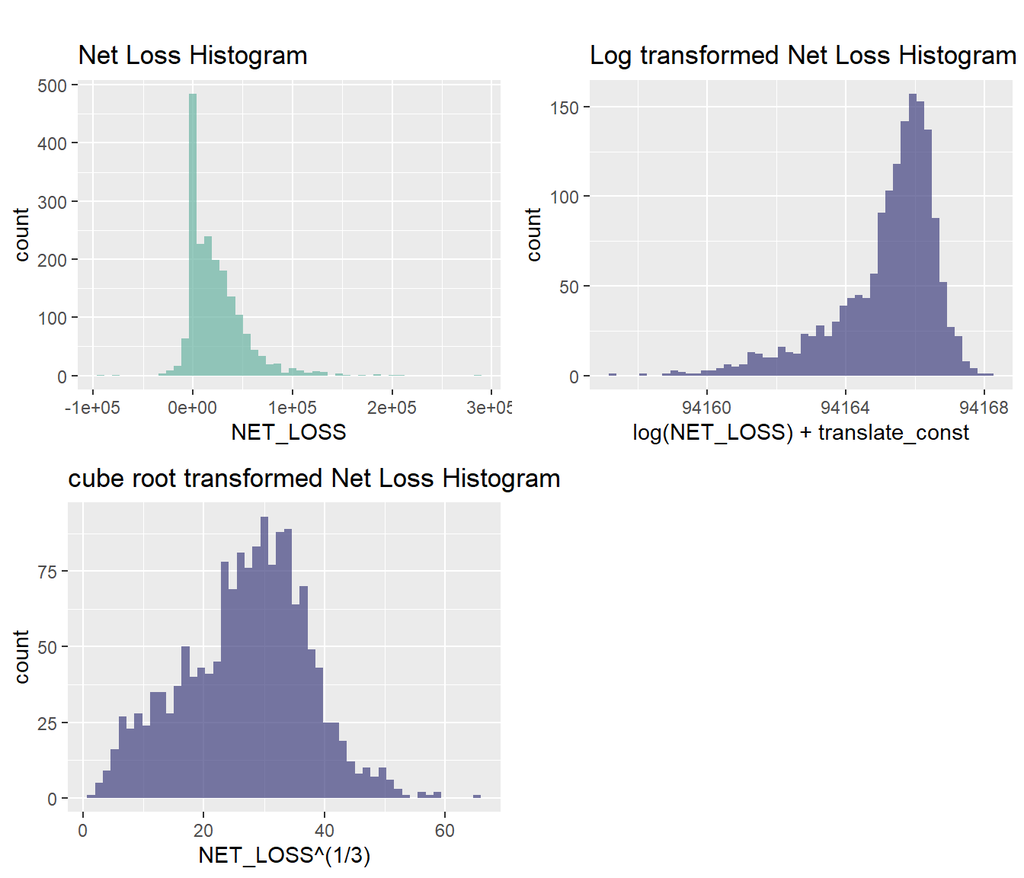

```r
p_trans_net_loss1 <- ggplot(df3[!is.na(df3$NET_LOSS),], aes(NET_LOSS)) +
  geom_histogram(bins = mybins, fill = '#69b3a2' ,alpha= 0.7) +
  ggtitle('Net Loss Histogram')

translate_const <- 1 - min(df3$NET_LOSS, na.rm = TRUE)
p_trans_net_loss2 <- ggplot(df3[!is.na(df3$NET_LOSS),], aes(log(NET_LOSS) + translate_const)) +
  geom_histogram(bins = mybins, fill = '#404080' ,alpha= 0.7) +
  ggtitle('Log transformed Net Loss Histogram')

p_trans_net_loss3 <- ggplot(df3[!is.na(df3$NET_LOSS),], aes(NET_LOSS^(1/3))) +
  geom_histogram(bins = mybins, fill = '#404080' ,alpha= 0.7) +
  ggtitle('cube root transformed Net Loss Histogram')
grid.arrange(p_trans_net_loss1, p_trans_net_loss2, p_trans_net_loss3, nrow = 2, top="")
```

## 2.2 New columns to better understand the data.

Considered the addition of `duration`, `actl_mo_payment`, and `mo_payment_diff`, but subsequently decided that they are only meaningful for `LAST_STAT == P`. The explanatory power of these variables largely disappear for `LAST_STAT` of D, C, S, or other types, as the loan often ended early and without all remaining UPB paid off. `duration` is kept for now because it does at least tell you how long it’s been going on, or how long it actually lasted.

```r
# Difference between interest rates
# Difference between oltv and ocltv
# Share of this loan among all loans, on this property. Or, oltv / ocltv (e.g. 25%/50% = 0.5)
# Theoretical monthly total mortgage payment (from borrowers/homeowners)
# Maybe a new column, orig_amt - NET_LOSS = final_result
# Maybe (for matured/prepaid) loans, calculate actual duration in months?

df4 <- df3 %>%
  mutate(rt_increase = LAST_RT - orig_rt, oltv_diff = ocltv - oltv, oltv_percentage = oltv / ocltv * 100,
         init_mo_payment = orig_amt * (orig_rt/100 * (1 + orig_rt/100)^orig_trm) / (-1 + (1 + orig_rt/100)^orig_trm),
         duration = interval(FRST_DTE, LAST_DTE) %/% months(1) + 1
         # min_rt = pmin(orig_rt, LAST_RT),
         # actl_mo_payment = orig_amt * (orig_rt/100 * (1 + orig_rt/100)^duration) / (-1 + (1 + orig_rt/100)^duration),
         # mo_payment_diff = actl_mo_payment - init_mo_payment
         ) %>%
  relocate(rt_increase, .after=LAST_RT) %>%
  relocate(oltv_diff, .after=ocltv) %>%
  relocate(oltv_percentage, .before=num_bo) %>%
  relocate(init_mo_payment, .before=orig_trm) %>%
  relocate(duration, .after=orig_trm)%>%
  select(-state)
  # relocate(actl_mo_payment, .after=init_mo_payment) %>%
  # relocate(mo_payment_diff, .after=actl_mo_payment) %>%

# show the first n rows of the new df.
df4[1:5, 1:34]
```

```
##        LOAN_ID   LAST_DTE LAST_STAT ORIG_CHN                  SELLER
## 1 100538106880 2002-08-01         P        C                   Other
## 2 100816784225 2002-09-01         P        B                   Other
## 3 101418327775 2001-12-01         P        R                   Other
## 4 101451865711 2001-04-01         P        C Jpmorgan Chase Bank, Na
## 5 102292538957 2002-08-01         P        C Jpmorgan Chase Bank, Na
##                              SERVICER orig_rt LAST_RT rt_increase orig_amt
## 1 Citimortgage Asset Management, Inc.   7.750   7.750           0    60000
## 2                               Other   8.000   8.000           0    94000
## 3                                       8.250   8.250           0    71000
## 4                                       7.875   7.875           0    76000
## 5             Jpmorgan Chase Bank, Na   7.750   7.750           0    50000
##    ORIG_VAL LAST_UPB init_mo_payment orig_trm duration   ORIG_DTE   FRST_DTE
## 1 109090.91 54366.18        4650.007      180       29 2000-02-01 2000-04-01
## 2 104444.44 91424.13        7520.000      360       31 2000-01-01 2000-03-01
## 3  94666.67 66470.38        5857.504      180       20 2000-03-01 2000-05-01
## 4  85393.26 75142.62        5985.000      360       15 1999-12-01 2000-02-01
## 5  68493.15 48878.37        3875.000      360       30 2000-01-01 2000-03-01
##   oltv ocltv oltv_diff oltv_percentage num_bo dti CSCORE_B CSCORE_C FTHB_FLG
## 1   55    55         0             100      1  30      782       NA        N
## 2   90    90         0             100      2  21      680      733        N
## 3   75    75         0             100      2  28      680      676        N
## 4   89    89         0             100      1  37      759       NA        N
## 5   73    73         0             100      1  22      781       NA        N
##   purpose PROP_TYP NUM_UNIT occ_stat   msa zip_3 mi_pct F30_DTE
## 1       C       SF        1        P 36540   680     NA    <NA>
## 2       P       SF        1        P 30700   685     25    <NA>
## 3       C       SF        1        P 36540   681     NA    <NA>
## 4       P       SF        1        P 30700   685     17    <NA>
## 5       P       SF        1        P     0   689     NA    <NA>
```

```r
# write.csv(x = df4, file = "df_new_cols_added.csv")
# save(df4, file = 'df4.Rdata')
```

## 2.3 Further Exploration of Dataframe

After removing all entries with `LAST_STAT == C`, we find that changes in interest rates seem to be a good indicator, increase or decrease. The share of Ps are lower for decreased or increased, and those didn’t change are the best.

```r
df4_NotC <- df4 %>%
  filter(LAST_STAT != 'C')
df4_C <- df4 %>%
  filter(LAST_STAT == 'C')

df4_NotC %>%
  mutate(rt_change = as.factor(ifelse(rt_increase > 0, 'inc', ifelse(rt_increase < 0, 'dec', 'const') ) ) ) %>%
  select(rt_change, rt_increase, LAST_STAT, orig_amt, ORIG_VAL, orig_rt, dti) %>%
  group_by(rt_change) %>%
  summarize(n=n(), P_share = (sum(LAST_STAT == 'P') / n()) , mean(orig_amt), mean(ORIG_VAL), mean(orig_rt), mean(dti, na.rm=TRUE))
```

```
## # A tibble: 3 x 7
##   rt_change      n P_share `mean(orig_amt)` `mean(ORIG_VAL)` `mean(orig_rt)`
##   <fct>      <int>   <dbl>            <dbl>            <dbl>           <dbl>
## 1 const     198938   0.981          148550.          204246.            5.18
## 2 dec          503   0.588          141435.          172555.            6.29
## 3 inc           10   0.6            129400           170071.            5.02
## # ... with 1 more variable: mean(dti, na.rm = TRUE) <dbl>
```

From the code below we can tell that having multiple mortgages on a single property doesn’t have a significant effect on the share of Ps. There’s an notable difference in `orig_amt` and `ORIG_VAL`, but that is slightly irrelevant for our purpose.

```r
df4_NotC %>%
  mutate(mtpl_mortgages = as.factor(ifelse(ocltv == oltv, 'single', 'multiple' ) ) ) %>%
  select(mtpl_mortgages, oltv, ocltv, LAST_STAT, orig_amt, ORIG_VAL, orig_rt, dti ) %>%
  group_by(mtpl_mortgages) %>%
  summarize(n=n(), P_share = sum(LAST_STAT == 'P') / n() , mean(orig_amt), mean(ORIG_VAL), mean(orig_rt), mean(dti, na.rm=TRUE))
```

```
## # A tibble: 2 x 7
##   mtpl_mortgages      n P_share `mean(orig_amt)` `mean(ORIG_VAL)`
##   <fct>           <int>   <dbl>            <dbl>            <dbl>
## 1 multiple        14921   0.976          182546.          262547.
## 2 single         184530   0.980          145781.          199444.
## # ... with 2 more variables: mean(orig_rt) <dbl>, mean(dti, na.rm = TRUE) <dbl>
```

Further investigation of `LAST_STAT != P` entries

```r
df4_C_no_delinquent <- df4_C %>%
  filter(is.na(F30_DTE))

# maybe more work on other types of LAST_STAT
```

# 3 Initial model for LAST_STAT

## 3.1 Prepare dataframe for modeling

Create a few new variables, remove some irrelevant variables, and modify a few others.

The response variable in this model will be `is_success`, a boolean variable that will be `TRUE` when `LAST_STAT` is P, and `FALSE` otherwise. Note that C will be filtered out and not considered.

```r
# transform dollar values with cube root?
# convert LAST_STAT and create new boolean value, as Y.
# remove LAST_STAT == C

# remove num_bo == NAs
# new col called CSCORE_AVG: average of 2 credit scores

# removed a few cols before building the model

df5 <- df4 %>%
  filter(LAST_STAT != 'C') %>%
  mutate(is_success = ifelse(LAST_STAT == 'P', TRUE, FALSE),
         CSCORE_AVG = ifelse(!is.na(CSCORE_B),CSCORE_B, CSCORE_C )/2 + ifelse(!is.na(CSCORE_C),CSCORE_C, CSCORE_B )/2,
         dti = ifelse( is.na(dti), 0, dti),
         mi_pct = ifelse( is.na(mi_pct), 0, dti),
         zip_3 = as.factor(zip_3)
         ) %>%
  # filter(!is.na(CSCORE_AVG),
  # dti = ifelse( is.na(dti), 0, dti)
  # )%>%        # this can be filtered out with glm() so I wont do it here for now.
  relocate(CSCORE_AVG, .after = dti) %>%
  select(is_success, everything(), -CSCORE_B, -CSCORE_C, -LAST_STAT, -LAST_DTE, -ORIG_DTE, -FRST_DTE, -duration, -rt_increase, -oltv_diff) %>%
  select(1:26, 40)

# sapply(df5 ,function(x) sum(is.na(x)))
# str(df5)
```

## 3.2 First attempt at modeling for `is_success`.

##### 3.2.0.0.1 Initial model 1

Everything that might be relevant were included.

```r
# mod_init <- glm(is_success ~. -LOAN_ID, family = binomial(link='logit'), data=df5, na.action = 'na.omit')
# summary(mod_init)
# coef(mod_init)
```

##### 3.2.0.0.2 Initial model 2

Removed `SELLER` because it just took up so much space, also too much variables to account for. Will explore further later.

```r
# mod_init2 <- glm(is_success ~. -LOAN_ID-SELLER, family = binomial(link='logit'), data=df5, na.action = 'na.omit')
# summary(mod_init2)
```

##### 3.2.0.0.3 Initial model 3

Removed both `SELLER` and `SERVICER` becasue to many factors, and that makes model too complex. Want simpler model for now. `zip_3` removed from model because it causes 11 “singularities”. Should try to add back later.

```r
mod_init3 <- glm(is_success ~. -LOAN_ID -SELLER -SERVICER -zip_3, family = binomial(link='logit'), data=df5, na.action = 'na.omit')
summary(mod_init3)
```

```
##
## Call:
## glm(formula = is_success ~ . - LOAN_ID - SELLER - SERVICER -
##     zip_3, family = binomial(link = "logit"), data = df5, na.action = "na.omit")
##
## Deviance Residuals:
##     Min       1Q   Median       3Q      Max
## -4.1224   0.0819   0.1301   0.2057   2.3804
##
## Coefficients:
##                   Estimate Std. Error z value Pr(>|z|)
## (Intercept)     -3.793e+00  3.477e+00  -1.091 0.275253
## ORIG_CHNC        2.582e-01  5.953e-02   4.337 1.44e-05 ***
## ORIG_CHNR        3.411e-01  6.093e-02   5.598 2.17e-08 ***
## orig_rt         -8.171e-01  5.213e-02 -15.675  < 2e-16 ***
## LAST_RT          9.328e-01  4.377e-02  21.310  < 2e-16 ***
## orig_amt         3.938e-06  1.568e-06   2.511 0.012041 *
## ORIG_VAL        -8.724e-07  3.411e-07  -2.558 0.010532 *
## LAST_UPB        -8.308e-06  1.201e-06  -6.917 4.60e-12 ***
## init_mo_payment  1.551e-04  2.076e-05   7.469 8.09e-14 ***
## orig_trm        -4.344e-03  3.036e-04 -14.312  < 2e-16 ***
## oltv             2.645e-02  3.726e-02   0.710 0.477824
## ocltv           -6.003e-02  3.702e-02  -1.621 0.104944
## oltv_percentage -2.812e-02  3.353e-02  -0.838 0.401762
## num_bo           6.484e-01  3.498e-02  18.534  < 2e-16 ***
## dti             -1.293e-02  1.570e-03  -8.232  < 2e-16 ***
## CSCORE_AVG       1.645e-02  3.332e-04  49.382  < 2e-16 ***
## FTHB_FLGN       -3.557e-01  8.185e-01  -0.435 0.663862
## FTHB_FLGY       -6.586e-01  8.195e-01  -0.804 0.421586
## purposeP         6.927e-01  5.286e-02  13.104  < 2e-16 ***
## purposeR         3.823e-01  4.701e-02   8.131 4.26e-16 ***
## purposeU        -1.429e-01  6.331e-01  -0.226 0.821386
## PROP_TYPCP       8.868e+00  3.247e+02   0.027 0.978215
## PROP_TYPMH      -1.067e+00  2.668e-01  -4.000 6.34e-05 ***
## PROP_TYPPU       2.749e-02  1.716e-01   0.160 0.872676
## PROP_TYPSF      -2.193e-01  1.633e-01  -1.343 0.179330
## NUM_UNIT         3.600e-02  1.139e-01   0.316 0.752017
## occ_statP        9.142e-01  6.965e-02  13.125  < 2e-16 ***
## occ_statS        4.658e-01  1.675e-01   2.781 0.005412 **
## msa10740         8.638e+00  3.247e+02   0.027 0.978779
```

[output cut: 13 more lines]

```
## msa43580         5.217e-02  1.596e-01   0.327 0.743829
## msa47260         7.978e+00  3.247e+02   0.025 0.980401
## mi_pct          -6.252e-03  1.341e-03  -4.663 3.12e-06 ***
## relo_flgY        3.373e-01  2.375e-01   1.420 0.155617
## ---
## Signif. codes:  0 '***' 0.001 '**' 0.01 '*' 0.05 '.' 0.1 ' ' 1
##
## (Dispersion parameter for binomial family taken to be 1)
##
##     Null deviance: 38681  on 192269  degrees of freedom
## Residual deviance: 32105  on 192224  degrees of freedom
##   (7181 observations deleted due to missingness)
## AIC: 32197
##
## Number of Fisher Scoring iterations: 11
```

```r
# alias(mod_init3)
```

From model above we can already see a few strong indicators. See above for more.

# 4 Questions/Comments: